# Portfolio 9- Mediation

April 24, 2022

For this portfolio, I’d like to pretend that I’m teaching an intro stats class on the topic of mediation. I want to be able to visualize the data points for students in a way that connects formulas to visible data points.

1. First, we must install packages / libraries, and a code that I need for Mac.

```r
r = getOption("repos")
r["CRAN"] = "http://cran.us.r-project.org"
options(repos = r)
```

```r
install.packages('tidyr')
install.packages('readr')
```

```r
library(ggplot2)
library(tidyr)
```

And install a mediation package:

```r
install.packages('mediation')
```

2. For our data, let’s use an excellent how-to from UVA, looking at the relationship between grades and happiness, with self-esteem as a potential mediator. I’m also going to add a categorical factor “Gender” that we can look at as well. In the UVA data set, the mediator is continuous/numeric.

https://data.library.virginia.edu/introduction-to-mediation-analysis/

```r
myData <- read.csv('http://static.lib.virginia.edu/statlab/materials/data/mediationData.csv')
```

I’ll convert the dataframe to a CSV so that I can manually add my Gender variable.

```r
library(readr)  #this is required to make write_csv work
write_csv(myData, "~/Documents/GitHub/Portfolio9-Mediation/MedData.csv")  #don’t forget .csv at the end
```

```r
library(readr)
MedDataVars <-read.csv("~/Documents/GitHub/Portfolio9-Mediation/MedDataVars.csv")
View(MedDataVars)
```

Step 1 of the mediation analysis is to verify a correlation between (X) Grades and (Y) happiness.

```r
model.0 <- lm(Y_hap ~ X_grades, MedDataVars)
summary(model.0)
```

```
##
## Call:
## lm(formula = Y_hap ~ X_grades, data = MedDataVars)
##
## Residuals:
##     Min      1Q  Median      3Q     Max
## -5.0262 -1.2340 -0.3282  1.5583  5.1622
##
## Coefficients:
##             Estimate Std. Error t value Pr(>|t|)
## (Intercept)   2.8572     0.6932   4.122 7.88e-05 ***
## X_grades      0.3961     0.1112   3.564 0.000567 ***
## ---
## Signif. codes:  0 '***' 0.001 '**' 0.01 '*' 0.05 '.' 0.1 ' ' 1
##
## Residual standard error: 1.929 on 98 degrees of freedom
## Multiple R-squared:  0.1147, Adjusted R-squared:  0.1057
## F-statistic:  12.7 on 1 and 98 DF,  p-value: 0.0005671
```

We’ve got ourselves a significant relationship between grades and happiness. 0.3961*** p< 0.001

Step 2 of the mediation analysis is to verify a correlation between (X) Grades and (M_se) our self-esteem mediator.

```r
model.M <- lm(M_se ~ X_grades, MedDataVars)
summary(model.M)
```

```
##
## Call:
## lm(formula = M_se ~ X_grades, data = MedDataVars)
##
## Residuals:
##     Min      1Q  Median      3Q     Max
## -4.3046 -0.8656  0.1344  1.1344  4.6954
##
## Coefficients:
##             Estimate Std. Error t value Pr(>|t|)
## (Intercept)  1.49952    0.58920   2.545   0.0125 *
## X_grades     0.56102    0.09448   5.938 4.39e-08 ***
## ---
## Signif. codes:  0 '***' 0.001 '**' 0.01 '*' 0.05 '.' 0.1 ' ' 1
##
## Residual standard error: 1.639 on 98 degrees of freedom
## Multiple R-squared:  0.2646, Adjusted R-squared:  0.2571
## F-statistic: 35.26 on 1 and 98 DF,  p-value: 4.391e-08
```

And now we see that we’ve got ourselves a significant relationship between grades and self-esteem. 0.56102 *** p< 0.001

Step 3 of the mediation analysis is to include our self-esteem mediator in looking at the relationship between X and Y.

```r
model.Y <- lm(Y_hap ~ X_grades + M_se, MedDataVars)
summary(model.Y)
```

```
##
## Call:
## lm(formula = Y_hap ~ X_grades + M_se, data = MedDataVars)
##
## Residuals:
##     Min      1Q  Median      3Q     Max
## -3.7631 -1.2393  0.0308  1.0832  4.0055
##
## Coefficients:
##             Estimate Std. Error t value Pr(>|t|)
## (Intercept)   1.9043     0.6055   3.145   0.0022 **
## X_grades      0.0396     0.1096   0.361   0.7187
## M_se          0.6355     0.1005   6.321 7.92e-09 ***
## ---
## Signif. codes:  0 '***' 0.001 '**' 0.01 '*' 0.05 '.' 0.1 ' ' 1
##
## Residual standard error: 1.631 on 97 degrees of freedom
## Multiple R-squared:  0.373,  Adjusted R-squared:  0.3601
## F-statistic: 28.85 on 2 and 97 DF,  p-value: 1.471e-10
```

X_grades = 0.0396, p = 0.719 -Notice that X_grades is NO LONGER significant. M_se = 0.6355, p < 0.001

The results above show that the effect of X on Y disappeared, when M_se is included. This is an example of “full mediation”. In this context, self-esteem fully mediates between (X) grades and (Y) happiness.

Finally, for bootstrapping.

```r
library(mediation)
results <- mediate(model.M, model.Y, treat='X_grades', mediator='M_se',
                   boot=TRUE, sims=500)
```

```
## Running nonparametric bootstrap
```

```r
summary(results)
```

```
##
## Causal Mediation Analysis
##
## Nonparametric Bootstrap Confidence Intervals with the Percentile Method
##
##                Estimate 95% CI Lower 95% CI Upper p-value
## ACME             0.3565       0.2159         0.51  <2e-16 ***
## ADE              0.0396      -0.2097         0.28   0.736
## Total Effect     0.3961       0.1448         0.65   0.004 **
## Prop. Mediated   0.9000       0.4967         2.21   0.004 **
## ---
## Signif. codes:  0 '***' 0.001 '**' 0.01 '*' 0.05 '.' 0.1 ' ' 1
##
## Sample Size Used: 100
##
##
## Simulations: 500
```

What we’re really looking for here is the mediation effect. The mediation effect is labeled “ACME.” ACME is 0.3565, which is statistically significant. Again, the goal of mediation analysis is to see whether this effect is statistically significant, which it is in this case.

3. Now, let’s take a closer visual look at interaction effects. For this, the following blog contains very useful background and code: https://cran.r-project.org/web/packages/interactions/readme/README.html

3.a) First, to install an interaction package.

```r
install.packages('interactions')
```

3.b) The Johnson-Neyman plot is one way to look at these effects.

```
## JOHNSON-NEYMAN INTERVAL
##
## The Johnson-Neyman interval could not be found. Is the p value for your
## interaction term below the specified alpha?
```

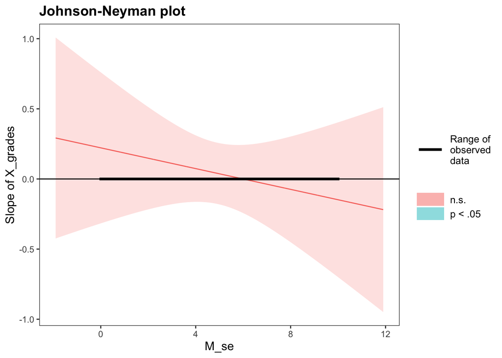

```
## SIMPLE SLOPES ANALYSIS
##
## Slope of X_grades when M_se = 2.958273 (- 1 SD):
##
##   Est.   S.E.   t val.      p
## ------ ------ -------- ------
##   0.11   0.15     0.76   0.45
##
## Slope of X_grades when M_se = 4.860000 (Mean):
##
##   Est.   S.E.   t val.      p
## ------ ------ -------- ------
##   0.04   0.11     0.38   0.70
##
## Slope of X_grades when M_se = 6.761727 (+ 1 SD):
##
##    Est.   S.E.   t val.      p
## ------- ------ -------- ------
##   -0.03   0.14    -0.20   0.84
```

```r
library(interactions)
interact1 <- lm(Y_hap ~ X_grades * M_se, data = MedDataVars)
sim_slopes(interact1, pred = X_grades, modx = M_se, jnplot = TRUE)
```

3c) Plotting the points is another very helpful illustration.

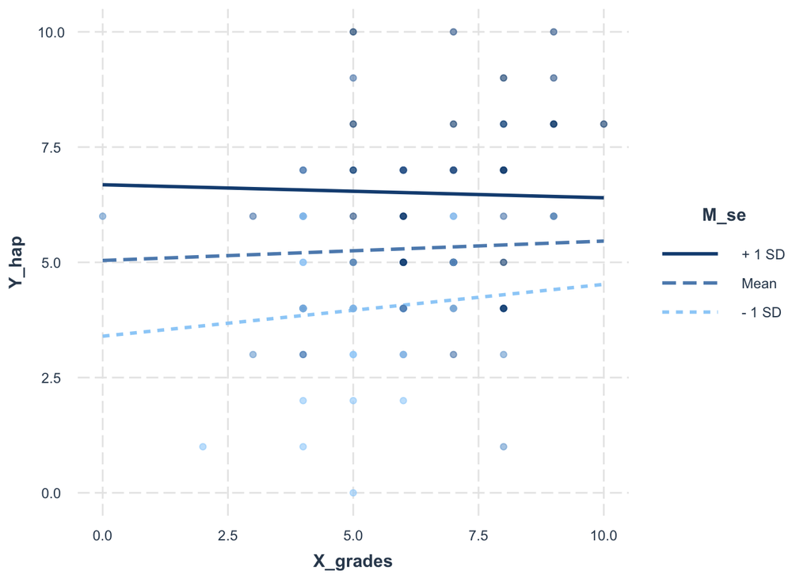

```r
interact_plot(interact1, pred = X_grades, modx = M_se, plot.points = TRUE)
```

4. I did not like the way the numeric mediatior graphs in the two graphs above. For that reason, I created a Gender variable to produce a clear, stark visual of the mediation relationship. For self-esteem scores from 0-5, I made those the Male scores, and Female scores were 6-10.

4.a) A recommended package for looking at interaction effects with categorical variables.

```r
install.packages("lme4")
```

4.b) In using the following code for the Johnson-Neyman plot, R Studio does not work well with factor moderators. With that in mind, the next steps will utilize a different code that plays along with our Male-Female variable.

```r
library(interactions)
library("lme4")
interact2 <- lm(Y_hap ~ X_grades * M_Gender, data = MedDataVars)
sim_slopes(interact2, pred = X_grades, modx = M_Gender, jnplot = TRUE)
```

```
## SIMPLE SLOPES ANALYSIS
##
## Slope of X_grades when M_Gender = Female:
##
##   Est.   S.E.   t val.      p
## ------ ------ -------- ------
##   0.36   0.20     1.74   0.09
##
## Slope of X_grades when M_Gender = Male:
##
##   Est.   S.E.   t val.      p
## ------ ------ -------- ------
##   0.08   0.14     0.56   0.57
```

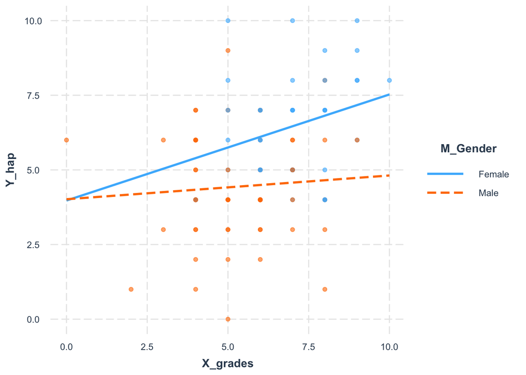

```r
interact_plot(interact2, pred = X_grades, modx = M_Gender, plot.points = TRUE)
```

4.d) Finally, one more way to obtain a similar graph.

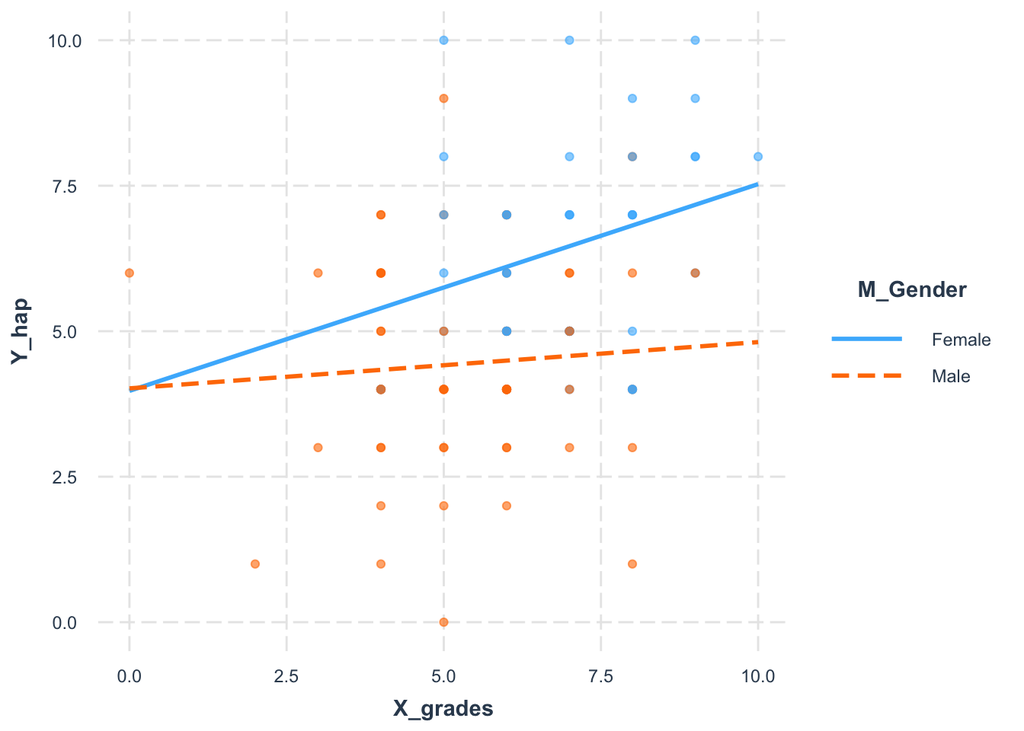

```r
interact3 <- lm(Y_hap ~ X_grades * M_Gender, data = MedDataVars)
interact_plot(interact3, pred = X_grades, modx = M_Gender, plot.points = TRUE)
```

Visualizing mediation is an excellent technique for showing the underlying relationships behind the formulas. The formulas can be grasped more easily with a digestible graph, like these!